# Homework 3

Samikshya

2022-10-17

##Question no 4.6

```r
library (resampledata)
```

```r
library (ggplot2)
library(dplyr)
library (tidyverse)
```

```
## ───────────────────────────────────────
## tidyverse 1.3.2 ──
```

```r
data("Recidivism") #using the dataset recidivism

N <- 10^4 -1
phat <- numeric(N)
for (i in 1:N)
{
samp <- sample(Recidivism$Recid, 25)
phat[i] <- mean(samp == "Yes") # proportion yes
}
```

4.6 a)

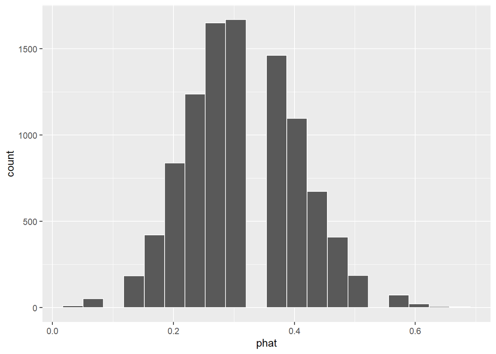

```r
ggplot(data=tibble(phat), mapping = aes(x=phat)) +
geom_histogram(bins = 20, color="white")
```

From the histogram above, we can see that the sample is closely following a normal distribution.

```r
sim.mean <- mean(phat) #mean is 0.317
sim.mean
```

```
## [1] 0.3172157
```

```r
#Standard Error:
sim.st <- sd(phat) #Standard Error = 0.093059
sim.st
```

```
## [1] 0.09441415
```

2. So, according to the theory, the estimate of the standard error is 0.093

```r
theory.sE <- sqrt((0.316 * (1-0.316))/25)
theory.sE  # The standard errir estiamted is 0.093
```

```
## [1] 0.09298258
```

```r
data("Recidivism") #using the dataset recidivism

N <- 10^4 -1
phat.250 <- numeric(N)
for (i in 1:N)
{
samp <- sample(Recidivism$Recid, 250)
phat.250[i] <- mean(samp == "Yes") # proportion yes
}
```

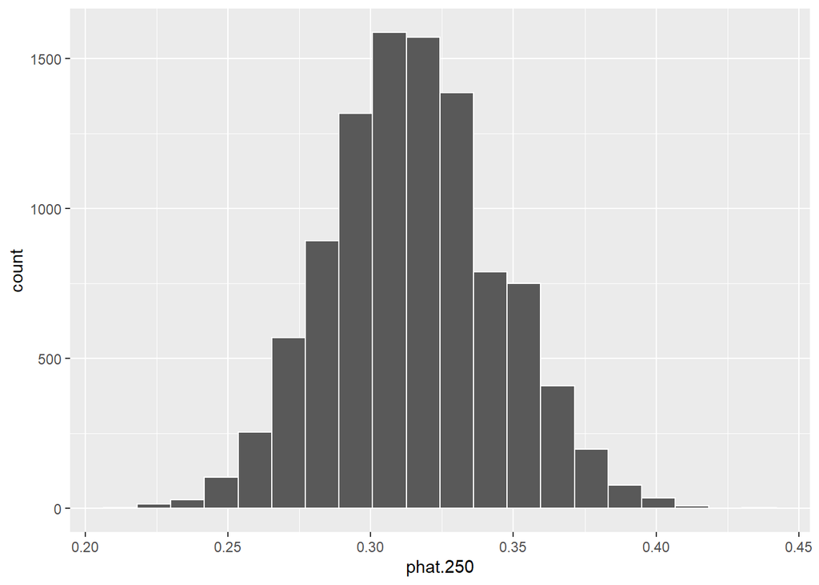

```r
ggplot(data=tibble(phat.250), mapping = aes(x=phat.250)) +
geom_histogram(bins = 20, color="white")
```

When we use the sample of sizes to be 250, the distribution also look normal

```r
mean(phat.250) #mean is 0.316
```

```
## [1] 0.3159504
```

```r
#Standard Error:
sd(phat.250)  #Standard error is 0.0291
```

```
## [1] 0.02908069
```

By Theory, Standard error = (0.316*0.684)/250 = sqr root of 0.000864576 = 0.0294

The standard error is equal to 3 decimal places.

```r
se.250 <- sqrt((0.316 * (1-0.316))/250)
se.250  # The thorotical SE is also 0.029 which is simialr to simulated mean
```

```
## [1] 0.02940367
```

We can see that the SE is significantly low (0.093 compared to 0.029) when the sample size is increased to 250 from 25. This tells that as the sample size increases, the standard error reduces.